# Trabalho da A2

Gustavo Tironi e Luis Felipe Marciano

2023-06-03

# 1 Formulação e documentação da ideia

A escolha da base se deu a partir de uma exploração no [**Kaggle**](https://www.kaggle.com/), na qual nos deparamos com a base de dados sobre os [jogadores draftado na NBA](https://www.kaggle.com/datasets/mattop/nba-draft-basketball-player-data-19892021). Definimos então, que essa seria a base utilizada. Analisando a base, vimos que, além de apresentar os jogadores, a posição no qual foram draftados e os times, desde 1989, também haviam as estatísticas de cada jogador ao longo de sua carreira. Conforme pode ser visualizado abaixo.

```r
base_de_dados <- read.csv("nbaplayersdraft.csv", sep = ",")

kable(head(base_de_dados), "html") %>% kable_styling("striped") %>% scroll_box(width = "100%")
```

| id | year | rank | overall_pick | team | player | college | years_active | games | minutes_played | points | total_rebounds | assists | field_goal_percentage | X3_point_percentage | free_throw_percentage | average_minutes_played | points_per_game | average_total_rebounds | average_assists | win_shares | win_shares_per_48_minutes | box_plus_minus | value_over_replacement |
| --- | --- | --- | --- | --- | --- | --- | --- | --- | --- | --- | --- | --- | --- | --- | --- | --- | --- | --- | --- | --- | --- | --- | --- |
| 1 | 1989 | 1 | 1 | SAC | Pervis Ellison | Louisville | 11 | 474 | 11593 | 4494 | 3170 | 691 | 0.510 | 0.050 | 0.689 | 24.5 | 9.5 | 6.7 | 1.5 | 21.8 | 0.090 | -0.5 | 4.4 |
| 2 | 1989 | 2 | 2 | LAC | Danny Ferry | Duke | 13 | 917 | 18133 | 6439 | 2550 | 1185 | 0.446 | 0.393 | 0.840 | 19.8 | 7.0 | 2.8 | 1.3 | 34.8 | 0.092 | -0.9 | 4.9 |
| 3 | 1989 | 3 | 3 | SAS | Sean Elliott | Arizona | 12 | 742 | 24502 | 10544 | 3204 | 1897 | 0.465 | 0.375 | 0.799 | 33.0 | 14.2 | 4.3 | 2.6 | 55.7 | 0.109 | 0.2 | 13.5 |
| 4 | 1989 | 4 | 4 | MIA | Glen Rice | Michigan | 15 | 1000 | 34985 | 18336 | 4387 | 2097 | 0.456 | 0.400 | 0.846 | 35.0 | 18.3 | 4.4 | 2.1 | 88.7 | 0.122 | 0.8 | 24.9 |
| 5 | 1989 | 5 | 5 | CHH | J.R. Reid | UNC | 11 | 672 | 15370 | 5680 | 3381 | 639 | 0.472 | 0.135 | 0.716 | 22.9 | 8.5 | 5.0 | 1.0 | 22.5 | 0.070 | -2.9 | -3.7 |
| 6 | 1989 | 6 | 6 | CHI | Stacey King | Oklahoma | 8 | 438 | 7406 | 2819 | 1460 | 387 | 0.478 | 0.235 | 0.707 | 16.9 | 6.4 | 3.3 | 0.9 | 10.9 | 0.071 | -3.4 | -2.7 |

Antes de partimos para a hipótese, cabe uma explicação sobre o processo de Draft da NBA.

## 1.1 O que é o Draft da NBA?

O Draft da NBA é o processo em que jogadores amadores são escolhidos por franquias e entram oficialmente na maior liga de basquetebol profissinal do mundo, a NBA. O evento é composto por duas rodadas de 30 escolhas cada, com uma ordem pré-definida. Os times se revezam e cada um seleciona um jogador por rodada. Ou seja, 60 atletas são recrutados. Portanto, há de se imaginar que os primeiros escolhidos do Draft são melhores jogadores e farão melhores performances em sua carreira na liga.

Com isso, surgiu o seguinte questionamento, que veio a se tornar a hipótese a ser respondida com esse trabalho.

## 1.2 Hipótese

**A posição em que o jogador foi draftado realmente tem correlação com o seu desempenho durante a carreira?**

Dessa forma, pretendemos validar ou invalidar a hipótese acima, a partir da visualização dos dados da base escolhida.

Para tal, inicialmente, pensamos em criar quatro gráficos categórico vs quantitativo, onde caso exista alguma correlação os jogadores escolhidos nas primeiras posições, devem ter estatísticas melhores do que aqueles escolhidos nas últimas. Sendo assim, para validar a hipótese, usando como métrica as estatísticas **pontos**, **rebotes**, **assistências** e **minutos jogados**, esperamos que os gráficos se apresentem conforme o rascunho abaixo.

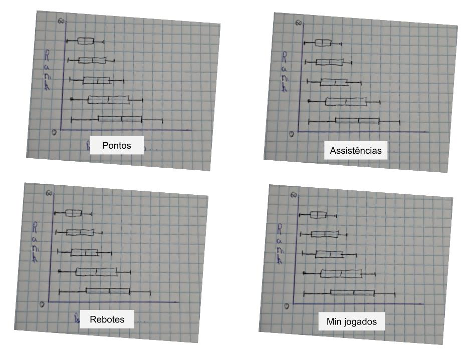

# 2 Análise Exploratória da base de dados

Como temos a hipótese a ser respondida em mente, trataremos a princípio apenas as variáveis pertinentes, sendo que, caso venha a se tornar necessário a inclusão de outras variáveis, iremos analisá-las posteriormente.

Antes de qualquer análise mais aprofundada, devemos entender nossa base de dados. Batendo o olho no arquivo **.cvs**, podemos ver que cada linha representa um jogador e cada coluna uma variável a respeito dele. Assim, podemos começar a tratar as variáveis. Para responder à hipótese, precisamos, acima de tudo, conseguir identificar a posição em que o jogador foi escolhido no draft. Para isso, temos as variáveis **rank** e **overall_pick**, que são o mesmo, e tratam exatamente da posição em que o jogador foi draftado. Essas, são variáveis qualitativas ordinais que vão de 1 a 60.

Tendo a posição definida, precisamos olhar agora para as variáveis que nos ajudarão a definir o desempenho do jogador. Previamente, definimos que as estatísticas **pontos**, **rebotes**, **assistências** e **minutos jogados** seriam as responsáveis por determinar o desempenho. Essa escolha vai conforme a comunidade de basquete, que frequentemente usa essas estatísticas para definir a grandeza de um jogador, principalmente os **pontos**. Contudo, entendendo a diversidade de posições no basquete, não é justo analisar apenas pelos pontos, e sim pelo conjunto da obra, ou seja, **pontos**, **rebotes** e **assistências**. Junto a isso, os **minutos jogados** são de extrema importância, já que um jogador importante para o time, jogará mais minutos em cada partida.

Analisando o banco de dados, vemos que a coluna **minutes_played** traz os minutos jogados, a coluna **points** traz os pontos totais, a coluna **total_rebounds** traz os rebotes e a coluna **assists** traz as assistências. Todas essas, são variáveis quantitativas discretas.

Com as variáveis devidamente, definidas, podemos começar a análise exploratória. Inicialmente, iremos aplicar a função **summary** em todas as variáveis, para observar seu comportamento.

```r
base_de_dados_resumida <- select(base_de_dados, points, minutes_played, total_rebounds, assists)

summary(base_de_dados_resumida)
```

```
##      points      minutes_played  total_rebounds     assists
##  Min.   :    0   Min.   :    0   Min.   :    0   Min.   :    0.0
##  1st Qu.:  265   1st Qu.:  838   1st Qu.:  128   1st Qu.:   46.0
##  Median : 1552   Median : 4204   Median :  656   Median :  257.0
##  Mean   : 3580   Mean   : 8399   Mean   : 1497   Mean   :  774.3
##  3rd Qu.: 5150   3rd Qu.:13246   3rd Qu.: 2139   3rd Qu.:  910.0
##  Max.   :37062   Max.   :52139   Max.   :15091   Max.   :12091.0
##  NA's   :253     NA's   :253     NA's   :253     NA's   :253
```

Já pudemos identificar a ocorrência de valores nulos na base. Analisando-a mais profundamente, podemos determinar que os valores nulos correspondem a jogadores que foram draftados, mas que nunca jogaram na NBA. Por isso, resolvemos desconsiderar esses valores, sem perda de dados significantes.

```r
base_de_dados_resumida <- na.omit(select(base_de_dados, points, minutes_played, total_rebounds, assists))

summary(base_de_dados_resumida)
```

```
##      points      minutes_played  total_rebounds     assists
##  Min.   :    0   Min.   :    0   Min.   :    0   Min.   :    0.0
##  1st Qu.:  265   1st Qu.:  838   1st Qu.:  128   1st Qu.:   46.0
##  Median : 1552   Median : 4204   Median :  656   Median :  257.0
##  Mean   : 3580   Mean   : 8399   Mean   : 1497   Mean   :  774.3
##  3rd Qu.: 5150   3rd Qu.:13246   3rd Qu.: 2139   3rd Qu.:  910.0
##  Max.   :37062   Max.   :52139   Max.   :15091   Max.   :12091.0
```

Agora, podemos a analisar unidimensional das variáveis que serão utilizadas.

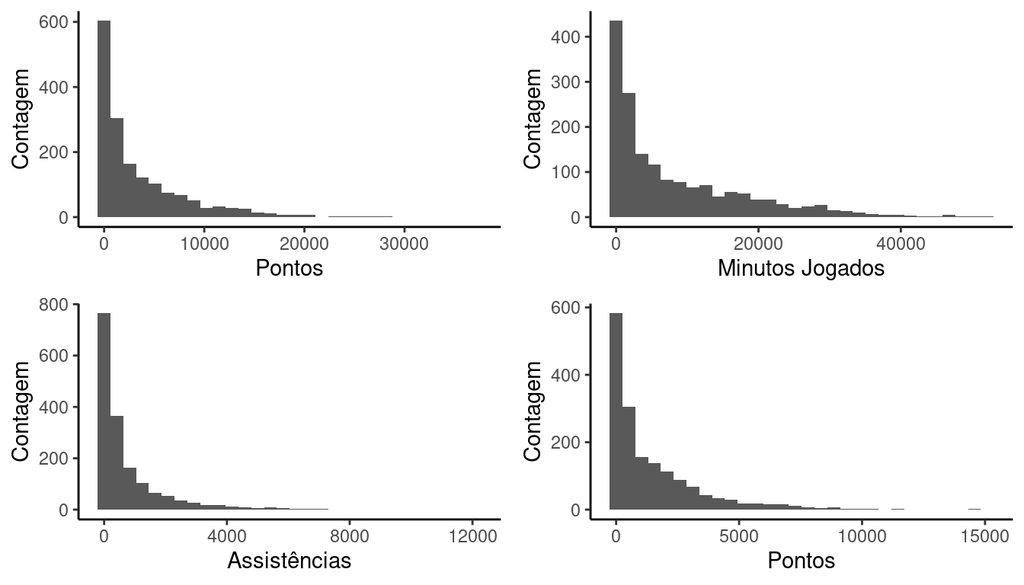

```r
p_points <- ggplot(data = base_de_dados_resumida, mapping = aes(x = points)) +
  geom_histogram() +
  labs(x = "Pontos", y = "Contagem")

p_minutes <- ggplot(data = base_de_dados_resumida, mapping = aes(x = minutes_played)) +
  geom_histogram() +
  labs(x = "Minutos Jogados", y = "Contagem")

p_assists <- ggplot(data = base_de_dados_resumida, mapping = aes(x = assists)) +
  geom_histogram() +
  labs(x = "Assistências", y = "Contagem")

p_rebounds <- ggplot(data = base_de_dados_resumida, mapping = aes(x = total_rebounds)) +
  geom_histogram() +
  labs(x = "Pontos", y = "Contagem")

grid.arrange(p_points, p_minutes,
             p_assists, p_rebounds,
             ncol=2, nrow=2)
```

Com essa análise, já podemos observar algo interessante. Podemos ver que há uma maior ocorrência de todas as variáveis nos valores mais baixos. Analisando a base de dados de forma visual, identificamos como uma possível causa disso, que jogadores que foram draftados em anos mais recentes, como 2020, têm pouco tempo de carreira e, consequentemente, têm menores estatísticas. Para confirmar isso, resolvemos replicar a analise, para a variavel pontos, separando por pelo ano em que o jogador foi draftado.

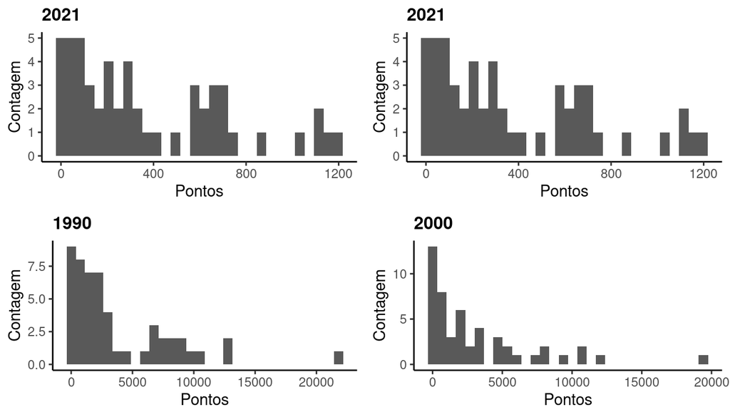

```r
dados_year_points <- na.omit(select(base_de_dados, points, year))

dados_2021 <- dados_year_points %>% filter(year == 2021)
dados_2020 <- dados_year_points %>% filter(year == 2020)
dados_1990 <- dados_year_points %>% filter(year == 1990)
dados_2000 <- dados_year_points %>% filter(year == 2000)

p_2021 <- ggplot(data = dados_2021, mapping = aes(x = points)) +
  geom_histogram() +
  labs(x = "Pontos", y = "Contagem", title = "2021")

p_2020 <- ggplot(data = dados_2020, mapping = aes(x = points)) +
  geom_histogram() +
  labs(x = "Pontos", y = "Contagem", title = "2020")

p_1990 <- ggplot(data = dados_1990, mapping = aes(x = points)) +
  geom_histogram() +
  labs(x = "Pontos", y = "Contagem", title = "1990")

p_2000 <- ggplot(data = dados_2000, mapping = aes(x = points)) +
  geom_histogram() +
  labs(x = "Pontos", y = "Contagem", title = "2000")

grid.arrange(p_2021, p_2021,
             p_1990, p_2000,
             ncol=2, nrow=2)
```

```r
base_de_dados_resumida <- na.omit(select(base_de_dados, points_per_game, average_assists, average_total_rebounds, average_minutes_played, rank))

summary(base_de_dados_resumida)
```

```
##  points_per_game  average_assists average_total_rebounds average_minutes_played
##  Min.   : 0.000   Min.   :0.000   Min.   : 0.000         Min.   : 0.00
##  1st Qu.: 3.400   1st Qu.:0.500   1st Qu.: 1.700         1st Qu.:11.00
##  Median : 6.200   Median :1.100   Median : 2.800         Median :17.70
##  Mean   : 7.276   Mean   :1.551   Mean   : 3.194         Mean   :18.13
##  3rd Qu.:10.000   3rd Qu.:2.100   3rd Qu.: 4.200         3rd Qu.:24.80
##  Max.   :27.200   Max.   :9.500   Max.   :13.300         Max.   :41.10
##       rank
##  Min.   : 1.0
##  1st Qu.:13.0
##  Median :26.0
##  Mean   :26.9
##  3rd Qu.:40.0
##  Max.   :60.0
```

Então são plotados os gráficos.

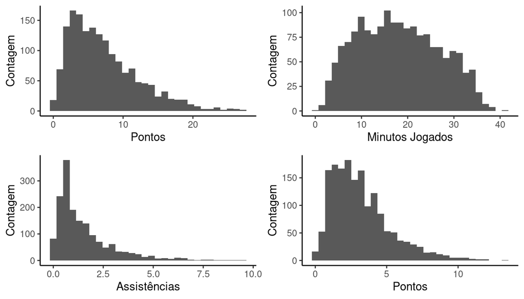

```r
p_points <- ggplot(data = base_de_dados_resumida, mapping = aes(x = points_per_game)) +
  geom_histogram() +
  labs(x = "Pontos", y = "Contagem")

p_minutes <- ggplot(data = base_de_dados_resumida, mapping = aes(x = average_minutes_played)) +
  geom_histogram() +
  labs(x = "Minutos Jogados", y = "Contagem")

p_assists <- ggplot(data = base_de_dados_resumida, mapping = aes(x = average_assists)) +
  geom_histogram() +
  labs(x = "Assistências", y = "Contagem")

p_rebounds <- ggplot(data = base_de_dados_resumida, mapping = aes(x = average_total_rebounds)) +
  geom_histogram() +
  labs(x = "Pontos", y = "Contagem")

grid.arrange(p_points, p_minutes,
             p_assists, p_rebounds,
             ncol=2, nrow=2)
```

Agora, podemos notar uma melhor distribuição dos dados. Contudo, para confirmar isso, repetiremos a analise dos anos mais recentes e de anos mais antigos, para comparação e confirmação.

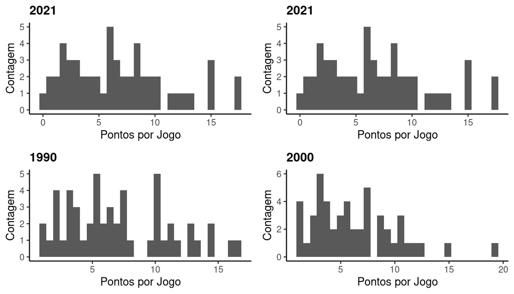

```r
dados_year_points <- na.omit(select(base_de_dados, points_per_game, year))

dados_2021 <- dados_year_points %>% filter(year == 2021)
dados_2020 <- dados_year_points %>% filter(year == 2020)
dados_1990 <- dados_year_points %>% filter(year == 1990)
dados_2000 <- dados_year_points %>% filter(year == 2000)

p_2021 <- ggplot(data = dados_2021, mapping = aes(x = points_per_game)) +
  geom_histogram() +
  labs(x = "Pontos por Jogo", y = "Contagem", title = "2021")

p_2020 <- ggplot(data = dados_2020, mapping = aes(x = points_per_game)) +
  geom_histogram() +
  labs(x = "Pontos por Jogo", y = "Contagem", title = "2020")

p_1990 <- ggplot(data = dados_1990, mapping = aes(x = points_per_game)) +
  geom_histogram() +
  labs(x = "Pontos por Jogo", y = "Contagem", title = "1990")

p_2000 <- ggplot(data = dados_2000, mapping = aes(x = points_per_game)) +
  geom_histogram() +
  labs(x = "Pontos por Jogo", y = "Contagem", title = "2000")

grid.arrange(p_2021, p_2021,
             p_1990, p_2000,
             ncol=2, nrow=2)
```

Novamente se confirma a distribuição mais igualitária dos dados, indicando que essas variáveis são mais eficazes para determinação do desempenho dos jogadores. Por fim, resolvemos analisar a variável **Rank**, que também será utilizada.

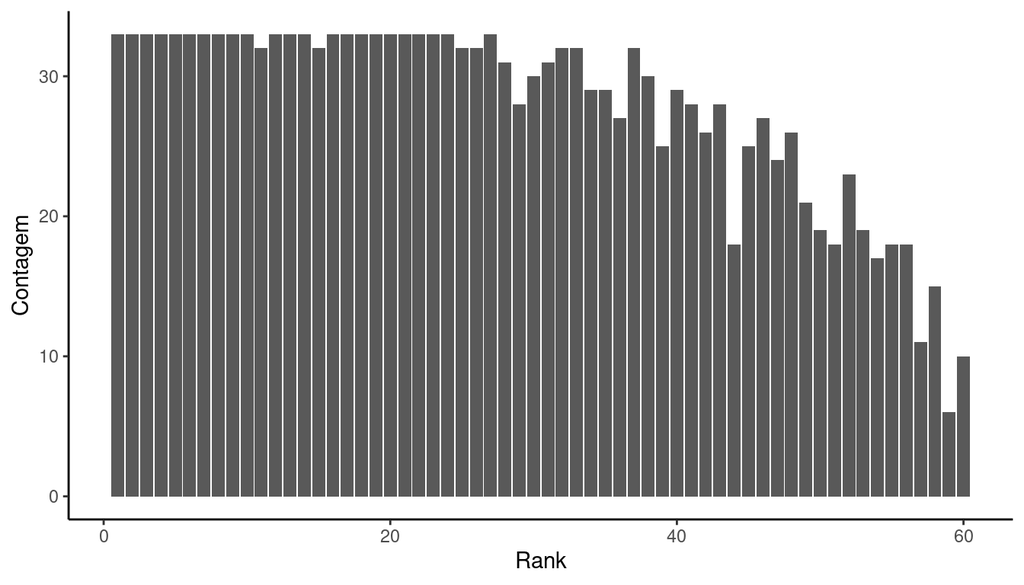

```r
ggplot(data = base_de_dados_resumida, mapping = aes(x = rank)) +
  geom_histogram(stat = "count") +
  labs(x = "Rank", y = "Contagem")
```

Com o gráfico, fica evidente que há menos dados de jogadores nas últimas posições do rank, contudo, isso era esperado, já que algumas posições do draft só começaram em anos mais recentes. Além disso, muito dos NA’s retirados estavam nessas posições.

Com isso, finalizamos nossa análise unidimensional, e podemos partir para a análise bidimensional.